# Data Science for Good: CareerVillage.org

# Introduction

CareerVillage.org is a nonprofit that crowdsources career advice for underserved youth. Founded in 2011 in four classrooms in New York City, the platform has now served career advice from 25,000 volunteer professionals to over 3.5M online learners. The platform uses a Q&A style similar to StackOverflow or Quora to provide students with answers to any question about any career.

The U.S. has almost 500 students for every guidance counselor. Underserved youth lack the network to find their career role models, making CareerVillage.org the only option for millions of young people in America and around the globe with nowhere else to turn.

To date, 25,000 volunteers have created profiles and opted in to receive emails when a career question is a good fit for them. This is where your skills come in. To help students get the advice they need, the team at CareerVillage.org needs to be able to send the right questions to the right volunteers. The notifications sent to volunteers seem to have the greatest impact on how many questions are answered.

# Objective

Develop a method to recommend relevant questions to the professionals who are most likely to answer them.

# Data Preprocessing

CareerVillage.org has provided several years of anonymized data and each file comes from a table in their database.

answers.csv: Answers are what this is all about! Answers get posted in response to questions. Answers can only be posted by users who are registered as Professionals. However, if someone has changed their registration type after joining, they may show up as the author of an Answer even if they are no longer a Professional.

comments.csv: Comments can be made on Answers or Questions. We refer to whichever the comment is posted to as the “parent” of that comment. Comments can be posted by any type of user. Our favorite comments tend to have “Thank you” in them :)

emails.csv: Each email corresponds to one specific email to one specific recipient. The frequency_level refers to the type of email template which includes immediate emails sent right after a question is asked, daily digests, and weekly digests.

group_memberships.csv: Any type of user can join any group. There are only a handful of groups so far.

groups.csv: Each group has a “type”. For privacy reasons we have to leave the group names off.

matches.csv: Each row tells you which questions were included in emails. If an email contains only one question, that email’s ID will show up here only once. If an email contains 10 questions, that email’s ID would show up here 10 times.

professionals.csv: We call our volunteers “Professionals”, but we might as well call them Superheroes. They’re the grown ups who volunteer their time to answer questions on the site.

questions.csv: Questions get posted by students. Sometimes they’re very advanced. Sometimes they’re just getting started. It’s all fair game, as long as it’s relevant to the student’s future professional success.

school_memberships.csv: Just like group_memberships, but for schools instead.

students.csv: Students are the most important people on CareerVillage.org. They tend to range in age from about 14 to 24. They’re all over the world, and they’re the reason we exist!

tag_questions.csv: Every question can be hashtagged. We track the hashtag-to-question pairings, and put them into this file.

tag_users.csv: Users of any type can follow a hashtag. This shows you which hashtags each user follows.

tags.csv: Each tag gets a name.

question_scores.csv: “Hearts” scores for each question.

answer_scores.csv: “Hearts” scores for each answer.

# Data Exploration

## Professionals

### Where are they from?

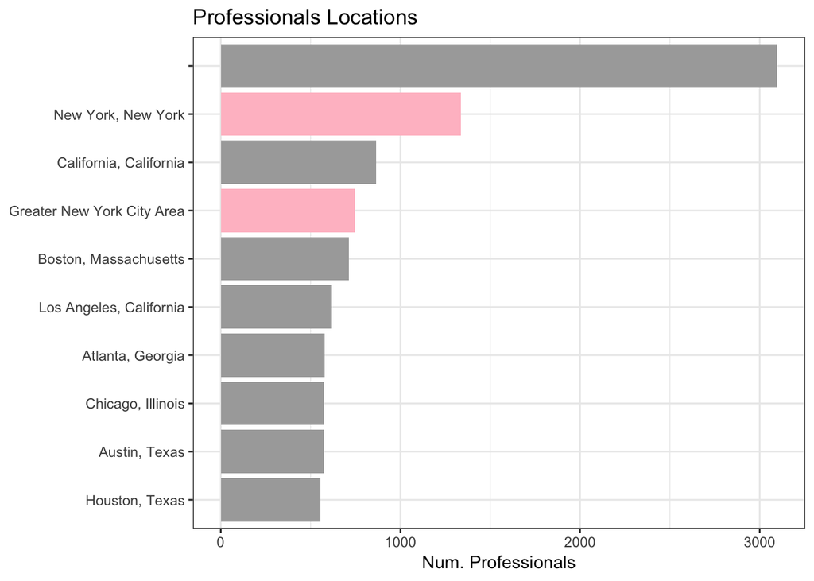

### Which industry are they in?

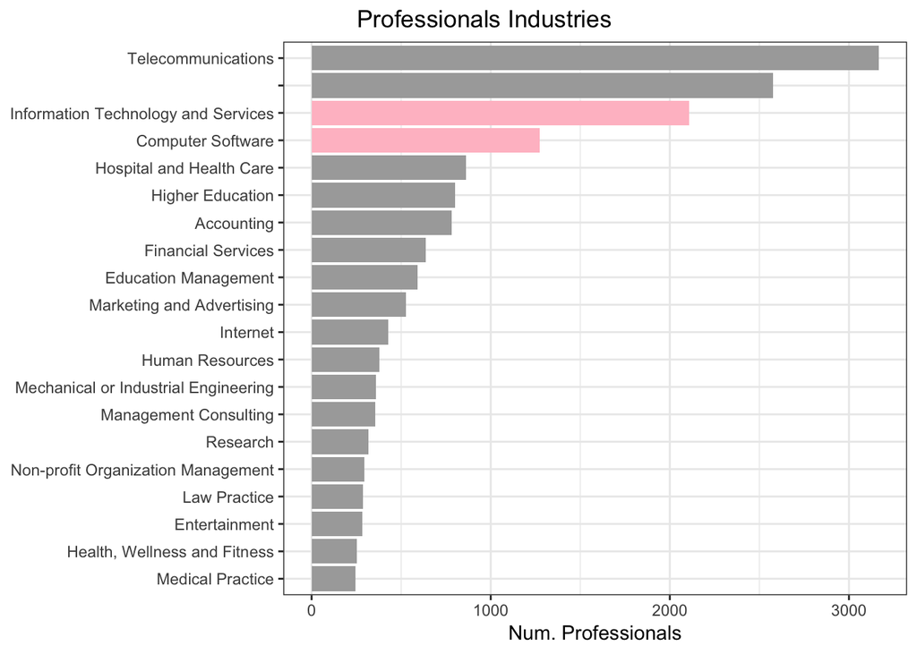

## Student

### Where are they from?

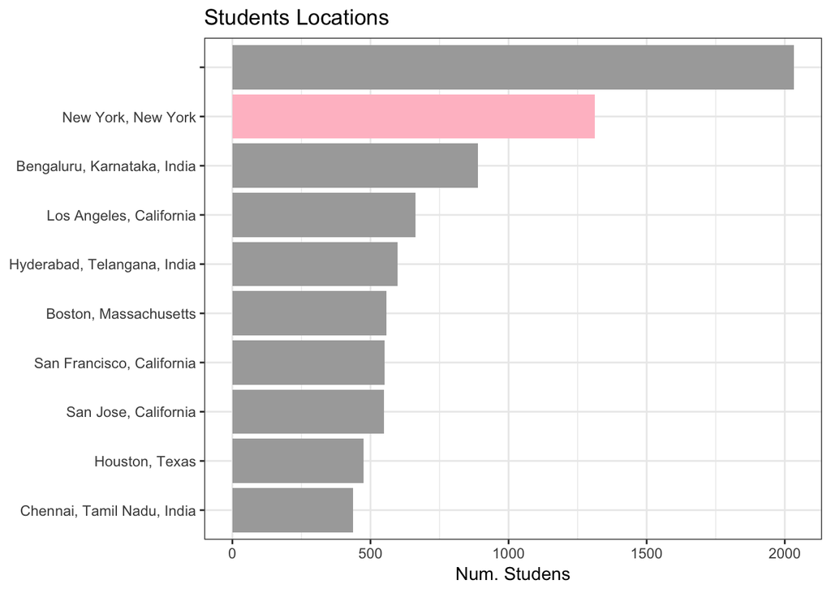

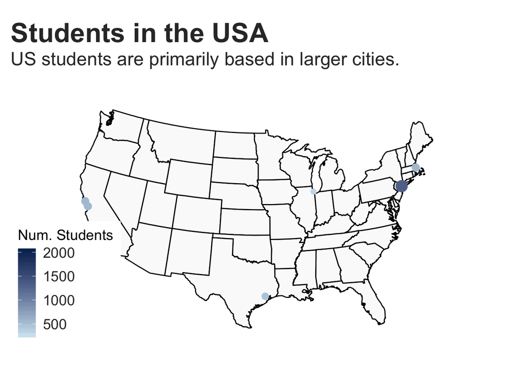

## Tags

### What’s the popular tags?

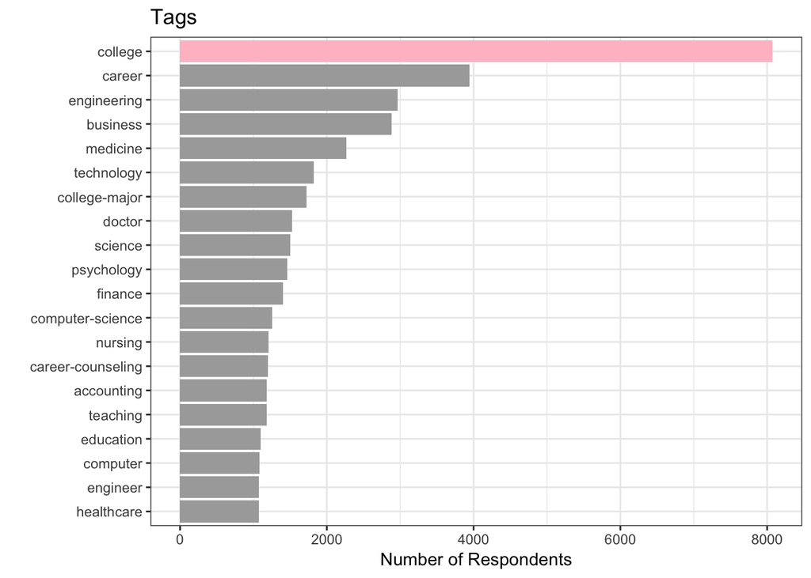

“Collage” related problems are in most concern.

### Tags of students

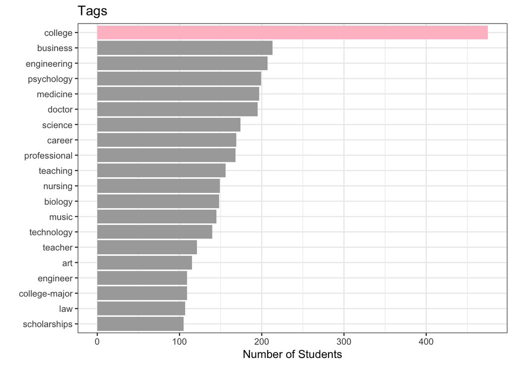

```r
merge5 <- merge(student, tag_u, by.x = "students_id",
                by.y = "tag_users_user_id")

merge55 <- merge(merge5, tag, by.x = "tag_users_tag_id",
                by.y = "tags_tag_id")




merge6 <- merge(pro, tag_u, by.x = "professionals_id",
                by.y = "tag_users_user_id")

merge66 <- merge(merge6, tag, by.x = "tag_users_tag_id",
                 by.y = "tags_tag_id")
Tag1 <-merge55 %>%
  group_by(tags_tag_name) %>%
  count() %>%
  ungroup() %>%
  filter(!is.na(tags_tag_name)) %>%
  mutate(filler = ifelse(tags_tag_name == "college", "y", "n")) %>%
  top_n(20, n) %>%
  ggplot(aes(reorder(tags_tag_name, n, FUN = min), n, fill = filler)) +
  geom_col() +
  labs(x = "", y = "Number of Students") +
  theme_bw() +
  ggtitle("Tags") +
  coord_flip()+scale_fill_manual(values = c("dark grey", "pink"), guide = F)

Tag1
```

### Tags of professionals

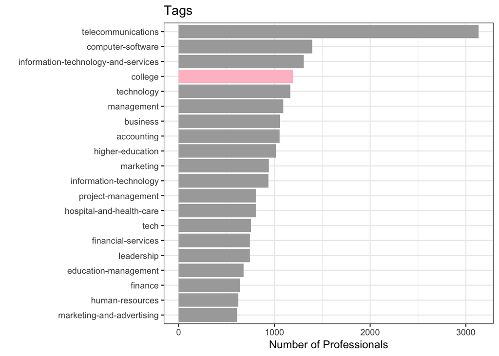

```r
Tag2 <-merge66 %>%
  group_by(tags_tag_name) %>%
  count() %>%
  ungroup() %>%
  filter(!is.na(tags_tag_name)) %>%
  mutate(filler = ifelse(tags_tag_name == "college", "y", "n")) %>%
  top_n(20, n) %>%
  ggplot(aes(reorder(tags_tag_name, n, FUN = min), n, fill = filler)) +
  geom_col() +
  labs(x = "", y = "Number of Professionals") +
  theme_bw() +
  ggtitle("Tags") +
  coord_flip()+scale_fill_manual(values = c("dark grey", "pink"), guide = F)

Tag2
```

## Questions

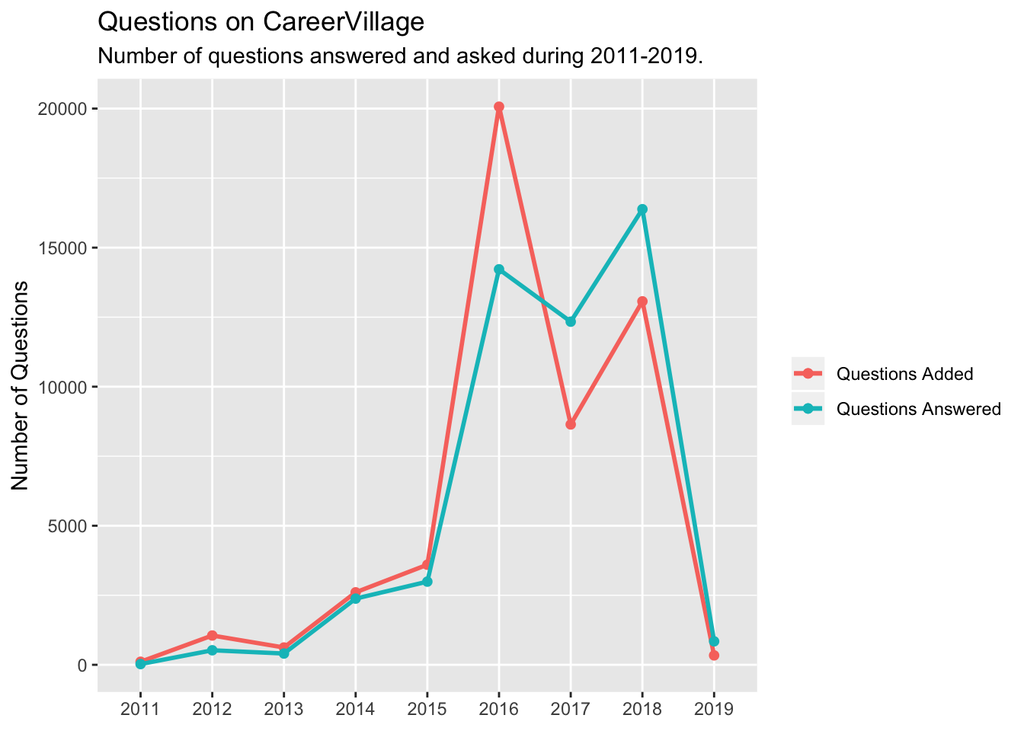

We observed that there are three years 2017, 2018 and 2019 that number of questions answered are more than questions asked.

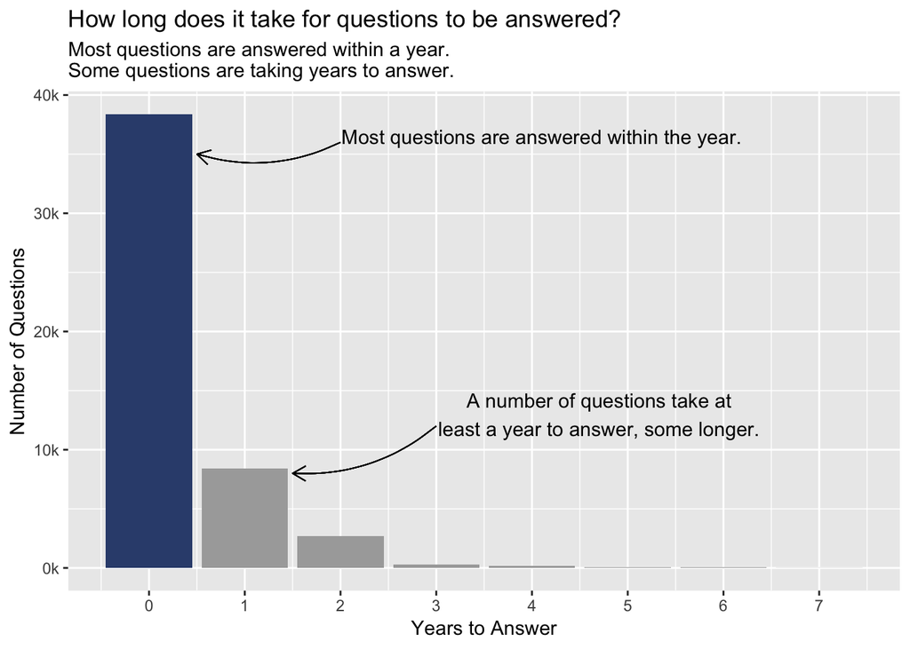

## Emails

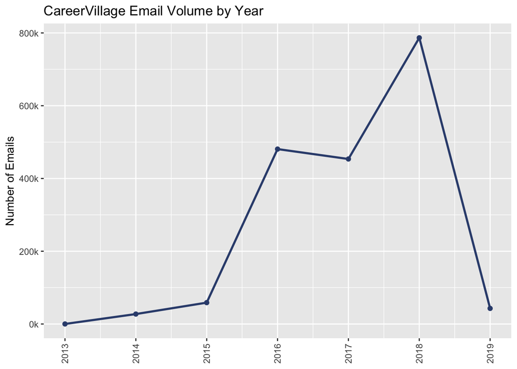

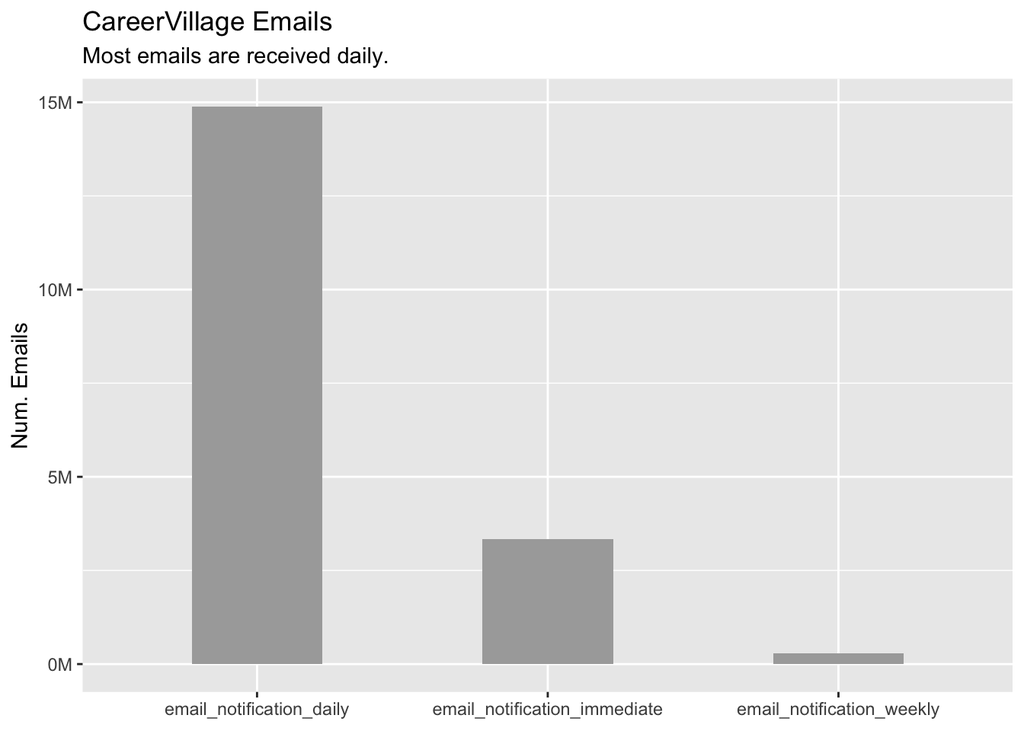

Most emails are recieved daily.

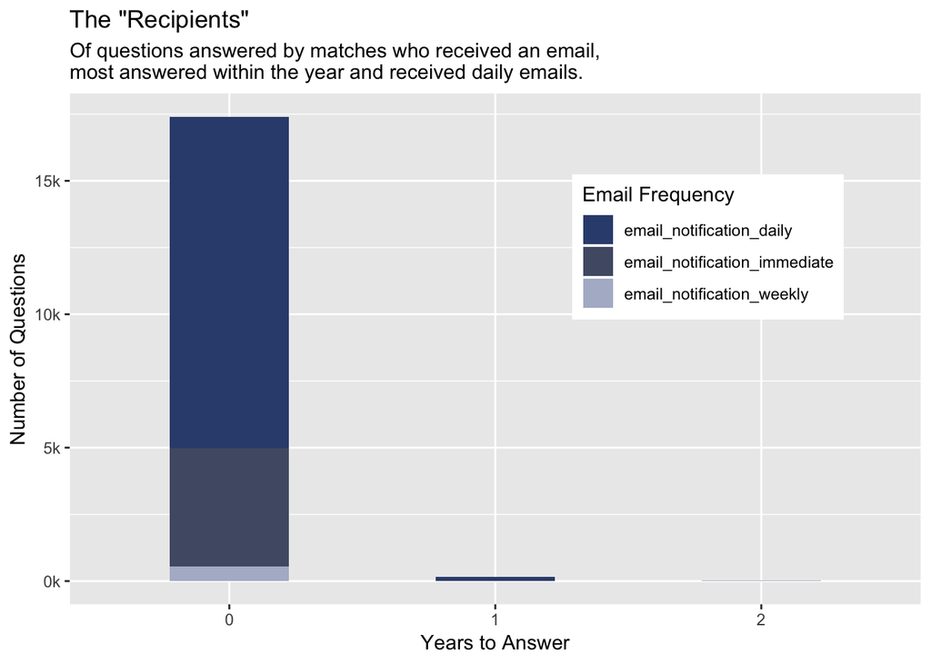

```r
qa_professionals <-
    qa_professionals %>%
    mutate(time_to_answer = as.integer(abs(date_added_no_time - date_answered_no_time)))

# join more tables
# ----------------
# emails and matches
em_match <- inner_join(match, email, by = c("matches_email_id" = "emails_id"))

# email matches and qa_professionals
qa_em_match <- inner_join(em_match, qa_professionals, by = c("matches_question_id" = "questions_id"))


rec_ans <-
    qa_em_match %>%
    filter(emails_recipient_id == answers_author_id)

rec_ans$rec_daily <- ifelse(rec_ans$emails_frequency_level == "daily", 1, 0)

years_ans_rec <-
    rec_ans %>%
    mutate(date_sent_no_time = as_date(emails_date_sent)) %>%
    mutate(sent_year = lubridate::year(date_sent_no_time)) %>%
    mutate(years_answered = -1 * (year_added - year_answered)) %>%
    mutate(year_from_email = (year_answered - sent_year)) %>%
    group_by(year_from_email, emails_frequency_level) %>%
    summarize(n = n())


years_ans_plot <-
    years_ans_rec %>%
    ggplot()+
    aes(x = as.character(year_from_email), y = n, fill = emails_frequency_level)+
    geom_col(width = .45)+
    theme(legend.position = c(.75,.70))+
    scale_fill_manual(values = c("#354c7c", "#505a74", "#b0b8ce"))+
    scale_y_continuous(labels = comma_format(scale = .001, suffix = "k"))+
    labs(x = "Years to Answer", y = "Number of Questions", fill = "Email Frequency", title = 'The "Recipients"',
         subtitle = "Of questions answered by matches who received an email,\nmost answered within the year and received daily emails.")

years_ans_plot
```

# Recommandation

1. Recommand questions based on user tag and question tag.
2. Generate key words for each professional, recommand questions based on key words of each professional.
3. Based on user’s past answered questions and tags build a score system, for each question give a score, based on scores we have send emails.

SEND EMAILS ON DIFFERENT TIME

4. Send emails during a specific time that most answers appeared.
5. People with different tags may answer in different time.
6. People with different location may answer in different time.
7. Different people are active during different time.
8. Discourage professionals from answering too old questions.